# Campus Waste and Sustainability Analytics

Shakshi

05 August 2026

# Introduction

This project analyzes campus waste generation and sustainability using a simulated data set. The objective is to identify waste generation patterns, evaluate recycling performance, and suggest improvements for sustainable campus management.

# Business Analytics Framework

## Type of Analytics

This project uses **Descriptive Analytics** and **Diagnostic Analytics**.

**Descriptive Analytics** is used to summarize and understand campus waste generation, recycling performance, and waste distribution.

**Diagnostic Analytics** is used to examine differences in waste generation across campus buildings and event types and to identify areas where recycling and waste segregation can be improved.

## Specific Business Question

**Which campus buildings and event types generate the most waste, and what are the current recycling and waste segregation performance levels?**

## Required Dataset(s)

The project requires campus waste management data containing the following variables:

- `Building`
- `Event_Type`
- `Total_Waste_kg`
- `Recycled_kg`
- `Segregation_Rate`

The current project uses the simulated dataset:

`Campus_Waste_Dataset.csv`

## Plan to Access the Dataset(s)

For the current project, the dataset will be accessed as a CSV file named `Campus_Waste_Dataset.csv` and loaded into R using `read.csv()`.

For a real campus implementation, the required data can be collected from campus waste collection records, recycling records, building-wise waste reports, event-wise waste records, and waste segregation records. The data can then be combined into a CSV file with the required variables and updated regularly for analysis.

# Load Dataset

```r
data <- read.csv("Campus_Waste_Dataset.csv", stringsAsFactors = FALSE)

head(data)
```

```
##         Date          Building    Event_Type Visitors Food_Waste_kg
## 1 2026-01-03  Academic Block B       Seminar      829          12.1
## 2 2026-01-04 Innovation Centre Regular Class      243           3.2
## 3 2026-01-05  Academic Block A  Sports Event      627           3.2
## 4 2026-01-06        Auditorium       Seminar      508           5.8
## 5 2026-01-07 Innovation Centre  Sports Event      857          26.4
## 6 2026-01-08  Academic Block A Cultural Fest      231          29.5
##   Plastic_Waste_kg Paper_Waste_kg Glass_Waste_kg Metal_Waste_kg
## 1             15.4            9.4            0.2            0.6
## 2              2.1            5.3            0.1            0.7
## 3              1.5            3.1            0.4            0.9
## 4             11.8            4.0            1.2            0.6
## 5             10.3            6.1            0.9            0.6
## 6             19.1            4.9            0.2            1.1
##   Organic_Waste_kg Total_Waste_kg Recycled_kg Segregation_Rate
## 1              7.5           45.2        30.2               89
## 2              4.0           15.5         8.0               69
## 3              2.2           11.3         7.1               84
## 4              4.5           27.8        14.0               67
## 5             14.5           58.8        33.1               75
## 6             14.0           68.7        38.1               74
```

```r
str(data)
```

```
## 'data.frame':    200 obs. of  13 variables:
##  $ Date            : chr  "2026-01-03" "2026-01-04" "2026-01-05" "2026-01-06" ...
##  $ Building        : chr  "Academic Block B" "Innovation Centre" "Academic Block A" "Auditorium" ...
##  $ Event_Type      : chr  "Seminar" "Regular Class" "Sports Event" "Seminar" ...
##  $ Visitors        : int  829 243 627 508 857 231 521 224 803 318 ...
##  $ Food_Waste_kg   : num  12.1 3.2 3.2 5.8 26.4 29.5 51.8 23.8 9.2 36.2 ...
##  $ Plastic_Waste_kg: num  15.4 2.1 1.5 11.8 10.3 19.1 3.8 12.5 2.4 6.1 ...
##  $ Paper_Waste_kg  : num  9.4 5.3 3.1 4 6.1 4.9 10 1.3 7.8 2.2 ...
##  $ Glass_Waste_kg  : num  0.2 0.1 0.4 1.2 0.9 0.2 0.1 1 0.6 1.2 ...
##  $ Metal_Waste_kg  : num  0.6 0.7 0.9 0.6 0.6 1.1 1.1 0.7 0.9 0.6 ...
##  $ Organic_Waste_kg: num  7.5 4 2.2 4.5 14.5 14 25 12.7 6 18.8 ...
##  $ Total_Waste_kg  : num  45.2 15.5 11.3 27.8 58.8 68.7 91.8 52.1 26.9 65.1 ...
##  $ Recycled_kg     : num  30.2 8 7.1 14 33.1 38.1 57.1 29.3 14.7 41 ...
##  $ Segregation_Rate: int  89 69 84 67 75 74 83 75 73 84 ...
```

```r
summary(data)
```

```
##      Date             Building          Event_Type           Visitors
##  Length:200         Length:200         Length:200         Min.   :187.0
##  Class :character   Class :character   Class :character   1st Qu.:351.5
##  Mode  :character   Mode  :character   Mode  :character   Median :542.0
##                                                           Mean   :543.6
##                                                           3rd Qu.:716.0
##                                                           Max.   :895.0
##  Food_Waste_kg   Plastic_Waste_kg Paper_Waste_kg   Glass_Waste_kg
##  Min.   : 2.20   Min.   : 1.000   Min.   : 1.200   Min.   :0.100
##  1st Qu.:10.47   1st Qu.: 5.425   1st Qu.: 4.100   1st Qu.:0.400
##  Median :22.40   Median :10.000   Median : 6.550   Median :0.700
##  Mean   :22.34   Mean   : 9.527   Mean   : 6.316   Mean   :0.689
##  3rd Qu.:32.40   3rd Qu.:12.925   3rd Qu.: 8.300   3rd Qu.:1.000
##  Max.   :64.20   Max.   :20.300   Max.   :14.900   Max.   :1.200
##  Metal_Waste_kg  Organic_Waste_kg Total_Waste_kg    Recycled_kg
##  Min.   :0.200   Min.   : 2.20    Min.   : 11.30   Min.   : 7.10
##  1st Qu.:0.400   1st Qu.: 6.15    1st Qu.: 34.75   1st Qu.:19.57
##  Median :0.600   Median :11.75    Median : 50.15   Median :28.70
##  Mean   :0.652   Mean   :11.74    Mean   : 51.26   Mean   :29.88
##  3rd Qu.:0.900   3rd Qu.:15.82    3rd Qu.: 65.28   3rd Qu.:38.23
##  Max.   :1.100   Max.   :30.60    Max.   :113.10   Max.   :73.00
##  Segregation_Rate
##  Min.   :66.00
##  1st Qu.:72.00
##  Median :77.00
##  Mean   :77.41
##  3rd Qu.:83.00
##  Max.   :89.00
```

# Data Cleaning

```r
sum(is.na(data))
```

```
## [1] 0
```

```r
data$Building <- as.factor(data$Building)
data$Event_Type <- as.factor(data$Event_Type)
```

# Total Waste by Building

```r
building_summary <- data %>%
group_by(Building) %>%
summarise(Total_Waste = sum(Total_Waste_kg))

building_summary
```

```
## # A tibble: 9 × 2
##   Building             Total_Waste
##   <fct>                      <dbl>
## 1 Academic Block A           1044.
## 2 Academic Block B            917.
## 3 Administrative Block       1068.
## 4 Auditorium                 1362.
## 5 Cafeteria                  2065.
## 6 Innovation Centre           896.
## 7 Library                    1033.
## 8 Main Gate Area              807.
## 9 Sports Complex             1060.
```

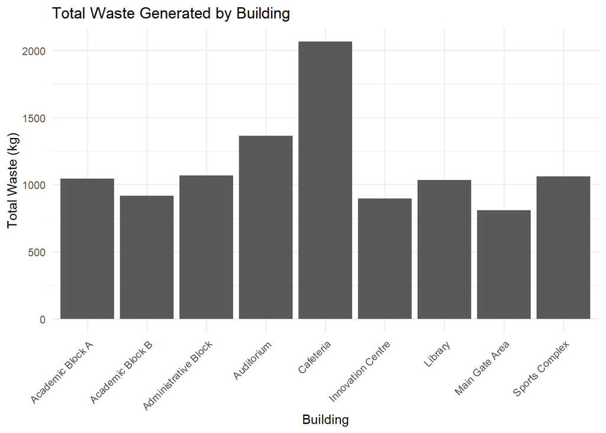

```r
ggplot(building_summary,
aes(x = Building, y = Total_Waste)) +
geom_col() +
theme_minimal() +
theme(axis.text.x = element_text(angle = 45, hjust = 1)) +
labs(title = "Total Waste Generated by Building",
x = "Building",
y = "Total Waste (kg)")
```

# Waste by Event Type

```r
event_summary <- data %>%
group_by(Event_Type) %>%
summarise(Total_Waste = sum(Total_Waste_kg))

event_summary
```

```
## # A tibble: 6 × 2
##   Event_Type    Total_Waste
##   <fct>               <dbl>
## 1 Cultural Fest       1977.
## 2 Examination         1530.
## 3 Regular Class       1840.
## 4 Seminar             2083.
## 5 Sports Event        1437.
## 6 Workshop            1385.
```

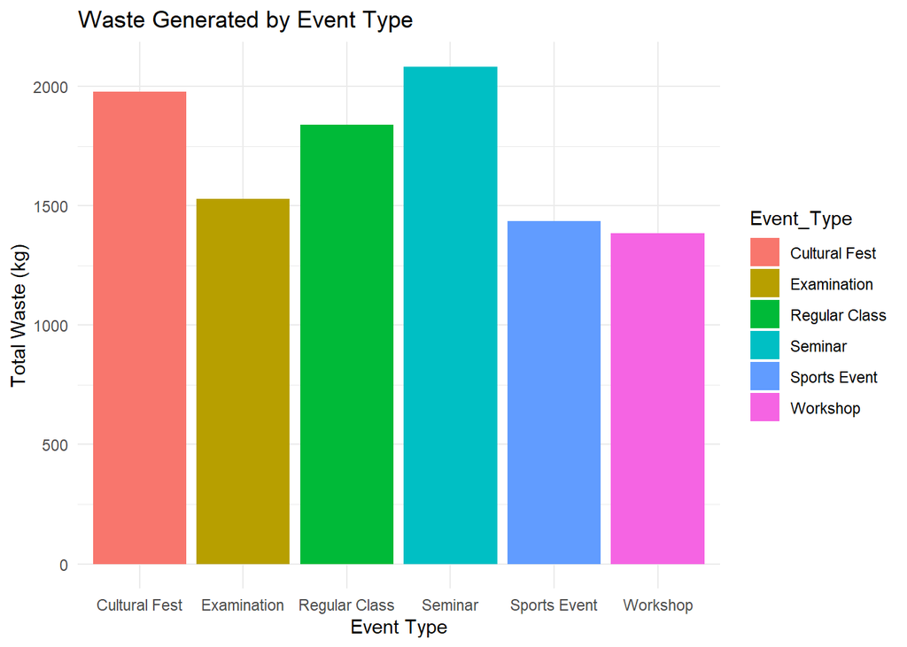

```r
ggplot(event_summary,
aes(x = Event_Type, y = Total_Waste, fill = Event_Type)) +
geom_col() +
theme_minimal() +
labs(title = "Waste Generated by Event Type",
x = "Event Type",
y = "Total Waste (kg)")
```

# Recycling Performance

```r
average_recycled <- mean(data$Recycled_kg)

average_segregation <- mean(data$Segregation_Rate)

average_recycled
```

```
## [1] 29.883
```

```r
average_segregation
```

```
## [1] 77.405
```

# Waste Distribution

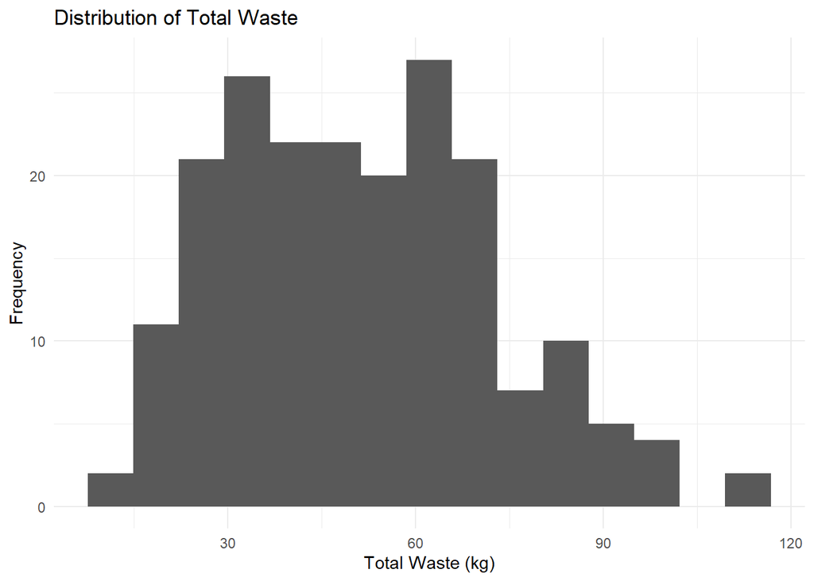

```r
ggplot(data,
aes(x = Total_Waste_kg)) +
geom_histogram(bins = 15) +
theme_minimal() +
labs(title = "Distribution of Total Waste",
x = "Total Waste (kg)",
y = "Frequency")
```

# Sustainability Scorecard

```r
scorecard <- data %>%
group_by(Building) %>%
summarise(
Average_Waste = mean(Total_Waste_kg),
Average_Recycled = mean(Recycled_kg),
Average_Segregation = mean(Segregation_Rate)
)

scorecard
```

```
## # A tibble: 9 × 4
##   Building             Average_Waste Average_Recycled Average_Segregation
##   <fct>                        <dbl>            <dbl>               <dbl>
## 1 Academic Block A              47.4             27.5                77.5
## 2 Academic Block B              43.6             24.8                75.3
## 3 Administrative Block          53.4             31.7                78.2
## 4 Auditorium                    42.6             24.7                77.7
## 5 Cafeteria                     82.6             49.8                79.9
## 6 Innovation Centre             40.7             23.9                78.5
## 7 Library                       51.7             28.2                73.0
## 8 Main Gate Area                53.8             32.0                79.8
## 9 Sports Complex                46.1             26.5                76.7
```

# Conclusion

The analysis shows that waste generation differs across campus buildings and event types. The cafeteria generates the highest total waste among the campus buildings, with 2065 kg, while seminars generate the highest total waste among the event types, with 2083 kg. The average recycled waste is 29.883 kg and the average segregation rate is 77.405%. These findings provide useful information for campus waste management and can help identify areas that require further attention to improve sustainability practices.